# Tutorial, Week 8: Machine learning 2

SECU0050

B Kleinberg

5 Mar 2020

Aims of this tutorial:

- finding stylistic patterns in YouTube vlogs
- examining content commonalities in missing person details
- replicating an authorship prediction example
- finding patterns in your own writing

*Note: this tutorial assumes that you have installed the `cluster` package.*

## Task 1: Examining style patterns in the YouTube corpus

Now use the techniques learned in the past weeks and extract, for each transcript, the readability (choose a metric yourself) and the number of words. Also check whether you might need to exclude some data.

|  | ntok | char_per_word |
| --- | --- | --- |
| 21122 | 2993 | 3.915469 |
| 20793 | 1673 | 3.962343 |
| 20395 | 932 | 3.964592 |
| 14187 | 2551 | 3.887887 |
| 16104 | 2832 | 3.910311 |
| 22479 | 1421 | 3.912034 |

Use these two variables with unsupervised machine learning (here: k-means) to assess whether there are underlying patterns in the way in which language (operationalised here through the readability and length of the transcript) is used:

Specifically, follow these steps:

1. plot the data
2. determine k
3. build a final k-means model
4. plot the data with cluster assignment *(Hint: you can get the clusters from the final model object)*
5. interpret the clusters

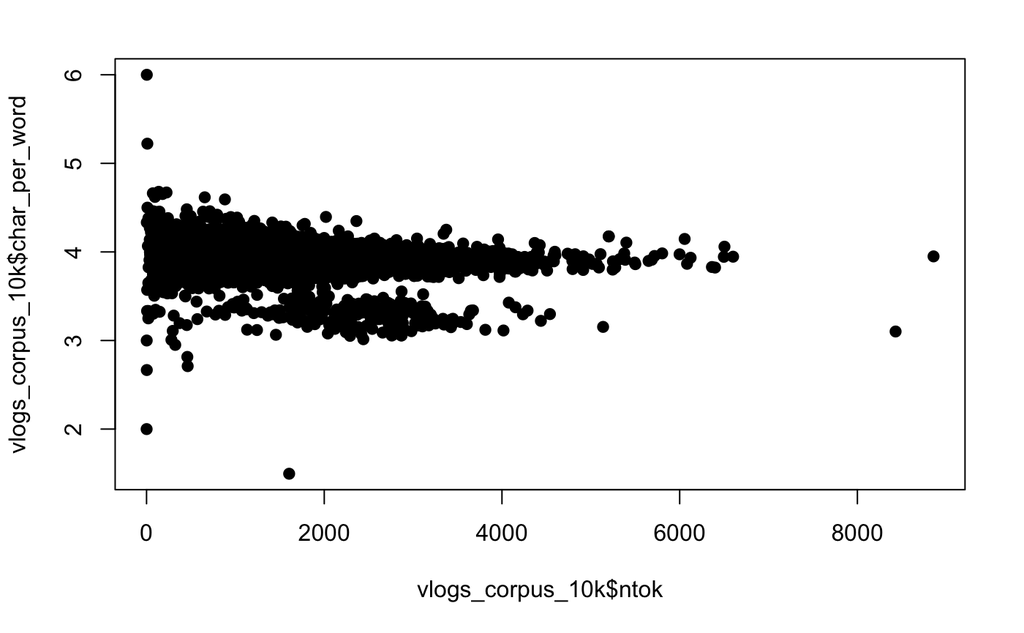

```r
# plotting the data (here: only two dimensions)
{plot(x = vlogs_corpus_10k$ntok
     , y = vlogs_corpus_10k$char_per_word
     , pch = 19)}
```

[figure not shown]

[figure not shown]

```r
# interpret clusters: look at the cluster means
final_kmeans$centers
```

```
      ntok char_per_word
1 2349.509      3.876106
2 1063.907      3.934227
```

## Task 2: Common topics in FBI missing persons data

Use the techniques from the previous weeks to extract common (here: use a sparsity correciton yourself) unigrams and bigrams from the text fields.

```r
# Use your own data here.
# Steps you need to follow:
# - extract ngrams
# - use ngrams frequencies as features
# - run the k-means model pipeline (as detailed in Task 1) on that data
# - interpret the clusters by their most prominent ngram differences
```

Once you have done so, use unsupervised learning to assess whether the use of these frequent unigrams and bigrams is patterned.

What do you conclude?

## Task 3: Authorship prediction example

For your final project, you are asked to engage in author attribution. After the data acquisition, you might decide to extract some linguistic features and build machine learning models.

One (of the various) approaches to do such a project is used in the quanteda tutorial on authorship prediction.

Try to replicate the example from https://quanteda.io/articles/pkgdown/replication/qss.html.

```r
# The replication is self-explanatory.
```

## Task 4: Finding patterns in your own writing

Now use the mini-corpus of your own coursework that you prepared in the previous weeks. With that corpus, run unsupervised models to examine whether there are patterns in the content and style of your work.

```r
# You can follow the same steps as in task 1 and task 2.
```

### (Extra task:) Predicting grades from linguistic style

From the same corpus select those pieces where you know the grade you received. Extract some features that relate to the style of your writing (since the content will depend on the topic) and use supervised modelling to predict the grade.

Note that:

- you will need a decent size of data and should only run this task if you have enough graded coursework
- the supervised task here differs from binary classification and takes the form of a regression with a numerical outcome (look at standard regression metrics for model evaluation, e.g. MAPE, RMSE).

```r
# Hint on regression metrics: https://topepo.github.io/caret/measuring-performance.html
```

## Homework

### Part 2: Packages for the next session

Install the following packages: